# Practical Machine Learning Course Project

Collin

06/20/2014

## Loading the data

First step was to load the entire training dataset provided and partition it into a training and testing set.

```r
library(caret)
training <- read.csv('pml-training.csv')
testing <- read.csv('pml-testing.csv')
partition <- createDataPartition(y=training$classe,
                                 p=.7,list=F)
train1 <- training[partition,]
test1 <- training[-partition,]
```

## Random forest

I decided that I would use random forests as the learning method because it was one of the methods we learned about in the third week of the class and it sounded like it would likely give good results. I considered trying multiple methods and then using voting to pick my answer, but after seeing how long it took the code to run I settled with just one random forest.

## First attempt at training and prediction

My first thought was to try to train it using all the other columns for learning.

```r
modFit <- train(classe ~ ., data=train1,method='rf')
```

After it ran for awhile without completing, I realized that it probably was too much data for prediction. I decided to be smarter about what data to use in the model.

## Selecting the data

To save on computation time I switched to using only 30% of the data for training, leaving the rest for testing. There were initially 19622 datapoints provided for training, so using 30% for training the model is still plenty of data. Ideally I would have used closer 70% for training, but I wanted the program to run in reasonable time.

```r
set.seed(3000)
partition <- createDataPartition(y=training$classe,
                                 p=.3,list=F)
train1 <- training[partition,]
test1 <- training[-partition,]
```

I tried to plot some of the variables against each other using the classe for the coloring. From the first plot I made I realized that I probably would not need to use all the columns of data in order to get good classification. This plot shows just two of the variables plotted and it is clear that there is a relation between the variables and the classe.

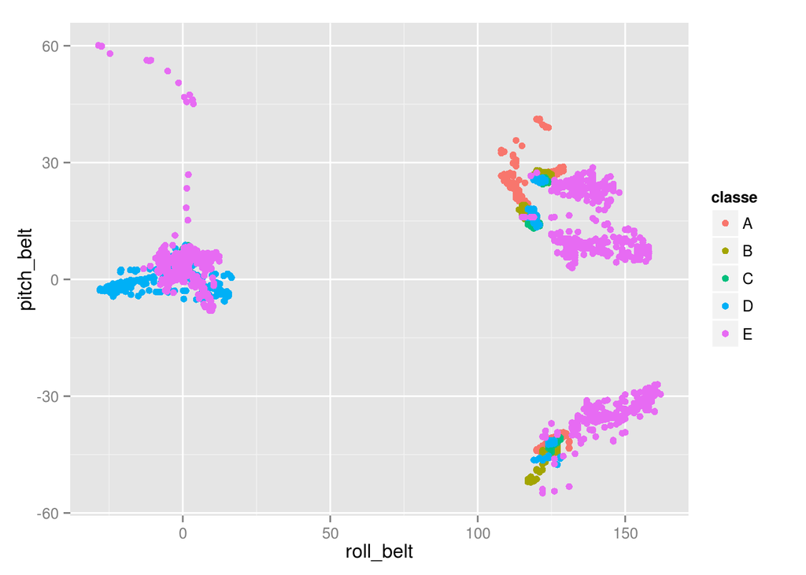

```r
qplot(x=roll_belt,y=pitch_belt,col=classe,data=train1)
```

The first training I tried to do with this data was a random forest using only the four main variables associated with belt, `roll_belt, pitch_belt, yaw_belt, total_accel_belt`. This was arbitrary, I only used them because they were the first columns that looked like meaningful data.

```r
modFit <- train(classe ~ roll_belt + pitch_belt + yaw_belt + total_accel_belt,
                data=train1, method='rf')
test1$predicted <- predict(modFit,test1)
test1$correct <- test1$classe==test1$predicted
confusionMatrix(test1$predicted,test1$classe)
```

```
## Confusion Matrix and Statistics
##
##           Reference
## Prediction    A    B    C    D    E
##          A 3507  203  228  195  107
##          B   97 2198  256   38   46
##          C  151  169 1793  124   16
##          D  101   62   95 1820   34
##          E   50   25   23   74 2321
##
## Overall Statistics
##
##                Accuracy : 0.848
##                  95% CI : (0.841, 0.853)
##     No Information Rate : 0.284
##     P-Value [Acc > NIR] : <2e-16
##
##                   Kappa : 0.806
##  Mcnemar's Test P-Value : <2e-16
##
## Statistics by Class:
##
##                      Class: A Class: B Class: C Class: D Class: E
## Sensitivity             0.898    0.827    0.749    0.809    0.920
## Specificity             0.925    0.961    0.959    0.975    0.985
## Pos Pred Value          0.827    0.834    0.796    0.862    0.931
## Neg Pred Value          0.958    0.959    0.948    0.963    0.982
## Prevalence              0.284    0.193    0.174    0.164    0.184
## Detection Rate          0.255    0.160    0.131    0.133    0.169
## Detection Prevalence    0.309    0.192    0.164    0.154    0.182
## Balanced Accuracy       0.912    0.894    0.854    0.892    0.952
```

This predicts the classe of the test variables with .849 accuracy, which is superb for using on 30% of the data and only four of the columns of the data. I decided to redo the model adding the four variables associated with dumbbell. This still omits most of the columns from the spreadsheet, but using all of the useful data would take far to long to calculate.

```r
modFit <- train(classe ~ roll_belt + pitch_belt + yaw_belt + total_accel_belt +
                roll_dumbbell+pitch_dumbbell+yaw_dumbbell + total_accel_dumbbell,
                data=train1,method='rf')
test1$predicted <- predict(modFit,test1)
test1$correct <- test1$classe==test1$predicted
confusionMatrix(test1$predicted,test1$classe)
```

```
## Confusion Matrix and Statistics
##
##           Reference
## Prediction    A    B    C    D    E
##          A 3727  112   77   85   23
##          B   47 2403   43   12   24
##          C   65  107 2181   52    6
##          D   64   28   94 2094    9
##          E    3    7    0    8 2462
##
## Overall Statistics
##
##                Accuracy : 0.937
##                  95% CI : (0.933, 0.941)
##     No Information Rate : 0.284
##     P-Value [Acc > NIR] : <2e-16
##
##                   Kappa : 0.92
##  Mcnemar's Test P-Value : <2e-16
##
## Statistics by Class:
##
##                      Class: A Class: B Class: C Class: D Class: E
## Sensitivity             0.954    0.904    0.911    0.930    0.975
## Specificity             0.970    0.989    0.980    0.983    0.998
## Pos Pred Value          0.926    0.950    0.905    0.915    0.993
## Neg Pred Value          0.982    0.977    0.981    0.986    0.994
## Prevalence              0.284    0.193    0.174    0.164    0.184
## Detection Rate          0.271    0.175    0.159    0.152    0.179
## Detection Prevalence    0.293    0.184    0.176    0.167    0.181
## Balanced Accuracy       0.962    0.947    0.945    0.957    0.987
```

Not surprisingly, this model did even better getting accuracy around 93%. I wanted to get the accuracy over 95%, so I decided to add eight more variables, the four associated with each of arm and forearm.

```r
modFit <- train(classe ~ roll_belt + pitch_belt + yaw_belt + total_accel_belt +
                roll_dumbbell+pitch_dumbbell+yaw_dumbbell + total_accel_dumbbell +
                roll_arm + pitch_arm + yaw_arm + total_accel_arm +
                roll_forearm + pitch_forearm + yaw_forearm + total_accel_forearm,
                data=train1,method='rf')
test1$predicted <- predict(modFit,test1)
test1$correct <- test1$classe==test1$predicted
confusionMatrix(test1$predicted,test1$classe)
```

```
## Confusion Matrix and Statistics
##
##           Reference
## Prediction    A    B    C    D    E
##          A 3876   26    1    2    2
##          B   22 2565   22    1    5
##          C    5   57 2344   30    4
##          D    3    7   26 2215    8
##          E    0    2    2    3 2505
##
## Overall Statistics
##
##                Accuracy : 0.983
##                  95% CI : (0.981, 0.985)
##     No Information Rate : 0.284
##     P-Value [Acc > NIR] : < 2e-16
##
##                   Kappa : 0.979
##  Mcnemar's Test P-Value : 0.000953
##
## Statistics by Class:
##
##                      Class: A Class: B Class: C Class: D Class: E
## Sensitivity             0.992    0.965    0.979    0.984    0.992
## Specificity             0.997    0.995    0.992    0.996    0.999
## Pos Pred Value          0.992    0.981    0.961    0.981    0.997
## Neg Pred Value          0.997    0.992    0.995    0.997    0.998
## Prevalence              0.284    0.193    0.174    0.164    0.184
## Detection Rate          0.282    0.187    0.171    0.161    0.182
## Detection Prevalence    0.284    0.190    0.178    0.164    0.183
## Balanced Accuracy       0.995    0.980    0.985    0.990    0.996
```

## Submission

```r
predictions <- predict(modFit,testing)
predictions
```

```
##  [1] B A B A A E D B A A B C B A E E A B B B
## Levels: A B C D E
```

When I submitted the files with these classifications, all of them were correct.

## Individual trees

We can try to look at an individual tree from the forest.

```r
tree1 <- getTree(modFit$finalModel,k=1,labelVar=T)
dim(tree1)
```

```
## [1] 751   6
```

```r
head(tree1)
```

```
##   left daughter right daughter            split var split point status
## 1             2              3        pitch_forearm       -34.2      1
## 2             4              5        roll_dumbbell       141.8      1
## 3             6              7            roll_belt       129.5      1
## 4             0              0                 <NA>         0.0     -1
## 5             8              9 total_accel_dumbbell         6.5      1
## 6            10             11             yaw_belt       169.5      1
##   prediction
## 1       <NA>
## 2       <NA>
## 3       <NA>
## 4          A
## 5       <NA>
## 6       <NA>
```

## Conclusion

In conclusion, I used the random forest learning method in the `train` function. Computation time was a huge limitation, so I had to be careful about how much data I used and how many variables were used for learning. I used 30% of the data for training, which is much smaller than typical, leaving 70% for testing the model. I started using 4 variables for learning, and ended up using 16 because it gave a significant increase in testing performance.

When I used the learning model of the data set aside for testing, its accuracy was over 97%. Since there were 20 data points to categorize in the assignment, I would have expected to get very few wrong, probably either zero or one. The model worked perfectly and got all 20 correct.